# Case Study 6

# 1 Introduction

The goal of this case study was to cleanse the selected data detailed below and then perform some simple analytics against the cleansed data.

# 2 Data Cleansing

Both datasets needs to have columns and rows removed in order to tidy the data.

## 2.1 Exploring the data set: Gross Domestic Product Ranking Table - GDP

```r
#Opening csv file in R and storing data set in a data frame.
GDA <- read.csv("C:\\Users\\kclark\\Personal\\SMU\\Doing Data Science MSDS 6306\\Unit 6\\GDP.csv", stringsAsFactors = FALSE, header = FALSE)

#Validating that GDA is a data frame
class(GDA)
```

```
## [1] "data.frame"
```

```r
#Checking the structure of the data frame and data types
str(GDA)
```

```
## 'data.frame':    243 obs. of  6 variables:
##  $ V1: chr  "" "" "" "" ...
##  $ V2: chr  "Gross domestic product 2014" "" "" "Ranking" ...
##  $ V3: logi  NA NA NA NA NA NA ...
##  $ V4: chr  "" "" "" "Economy" ...
##  $ V5: chr  "" "" "(millions of" "US dollars)" ...
##  $ V6: chr  "" "" "" "" ...
```

```r
#View the first 10 records for the GDA dataset
head(GDA)
```

```
##    V1                          V2 V3            V4           V5 V6
## 1     Gross domestic product 2014 NA
## 2                                 NA
## 3                                 NA               (millions of
## 4                         Ranking NA       Economy  US dollars)
## 5                                 NA
## 6 USA                           1 NA United States   17,419,000
```

```r
#view the last 10 records of the GDA dataset
tail(GDA)
```

```
##     V1
## 238
## 239
## 240
## 241
## 242
## 243
##                                                                                                                                                V2
## 238                                                                                                                           .. Not available.
## 239                            Note: Rankings include only those economies with confirmed GDP estimates. Figures in italics are for 2013 or 2012.
## 240      a. Based on data from official statistics of Ukraine and Russian Federation; by relying on these data, the World Bank does not intend to
## 241 make any judgment on the legal or other status of the territories concerned or to prejudice the final determination of the parties' claims.
## 242        b. Includes Former Spanish Sahara.  c. Covers mainland Tanzania only. d. Data are for the area controlled by the government of Cyprus.
## 243                                                                            e. Excludes Abkhazia and South Ossetia.  f. Excludes Transnistria.
##     V3 V4 V5 V6
## 238 NA
## 239 NA
## 240 NA
## 241 NA
## 242 NA
## 243 NA
```

### 2.1.1 Row and Column Selections for GDP-Ranking Dataset

The first 5 rows of the GDA data set includes the variable names and blanks. The last 7 rows include information about the data set. The first 5 rows and the last 7 rows are removed because they add no value to the data to be analyzed.

```r
#This statement will only keep rows 6 to 236 and a new version of the dataset - GDA1 is created.
GDA1 <- GDA[6:236,]
```

The current GDA1 data set had 6 columns, but only 4 actually contain the data for the case study. The code below will remove the extra columns that are not needed.

```r
#Remove columns 3 and 6 from the dataset by only selecting 1, 2, 4, and 5
GDA1 <- GDA1[c(1,2,4,5)]
```

### 2.1.2 Adding Variable Names to the Dataset

Names to each variable are added to the data set. The industry standard of capitalizing each word was applied. The variable names are human readable and self-explanatory.

```r
#Add Names to the variables in the data set
names(GDA1) <- c("CountryCode","Ranking","Country", "Economy")
```

### 2.1.3 Removing Blank Records and Bad data in the Dataset

There are a couple of blank records still within the data set. Set the blank variables to NA for blank rows and then remove them from the data set and create a new data set GDA2

```r
#sets the blank variables to NA where entire rows are blank if GDA - Economy variable is blank
GDA1[GDA1==""] <- NA

#Remove rows where all columns are NAs
GDA2 <- GDA1[apply(GDA1,1,function(x)any(!is.na(x))),]
```

The data set GDA2 still contains records where the Economy field does not have an applicable value stored in it - " .. “. The identified rows below will be removed from the GDA2 data set.

```r
#Find the rows where GDA2$Economy = " .. "
fslines <- which(GDA2$Economy == " .. ")

# view the record numbers for the rows that were identified
fslines
```

```
##  [1] 196 197 198 199 200 201 202 203 204 205 206 207 208 209 210 211 212
## [18] 213 214
```

```r
#remove identified rows and create a new data set GDA3
GDA3 <- GDA2[-which(GDA2$Economy == " .. "), ]
```

### 2.1.4 Final Dataset for GDP-Ranking

The final dataset for GDP-Ranking is cleansed and ready to use

```r
#view dataset GDA3
GDA3
```

```
##     CountryCode Ranking                        Country    Economy
## 6           USA       1                  United States 17,419,000
## 7           CHN       2                          China 10,354,832
## 8           JPN       3                          Japan  4,601,461
## 9           DEU       4                        Germany  3,868,291
## 10          GBR       5                 United Kingdom  2,988,893
## 11          FRA       6                         France  2,829,192
## 12          BRA       7                         Brazil  2,416,636
## 13          ITA       8                          Italy  2,141,161
## 14          IND       9                          India  2,048,517
## 15          RUS      10             Russian Federation  1,860,598
## 16          CAN      11                         Canada  1,785,387
## 17          AUS      12                      Australia  1,454,675
## 18          KOR      13                    Korea, Rep.  1,410,383
## 19          ESP      14                          Spain  1,381,342
```

[output cut: 195 more lines]

## 2.2 Exploring the Dataset: Country Data

```r
#Read the csv file into R and storing the data in a data frame named CountryData
CountryData <- read.csv("C:\\Users\\kclark\\Personal\\SMU\\Doing Data Science MSDS 6306\\Unit 6\\country.csv", stringsAsFactors = FALSE, header = FALSE)

#Validating that CountryData is a data frame
class(CountryData)
```

```
## [1] "data.frame"
```

```r
#Checking the structure of the data frame and data types
str(CountryData)
```

```
## 'data.frame':    242 obs. of  31 variables:
##  $ V1 : chr  "Country Code" "ABW" "ADO" "AFG" ...
##  $ V2 : chr  "Short Name" "Aruba" "Andorra" "Afghanistan" ...
##  $ V3 : chr  "Table Name" "Aruba" "Andorra" "Afghanistan" ...
##  $ V4 : chr  "Long Name" "Aruba" "Principality of Andorra" "Islamic State of Afghanistan" ...
##  $ V5 : chr  "2-alpha code" "AW" "AD" "AF" ...
##  $ V6 : chr  "Currency Unit" "Aruban florin" "Euro" "Afghan afghani" ...
##  $ V7 : chr  "Special Notes" "SNA data for 2000-2011 are updated from official government statistics; 1994-1999 from UN databases. Base year has changed from"| __truncated__ "" "Fiscal year end: March 20; reporting period for national accounts data: FY (from 2013 are CY). National accounts data a…
##  $ V8 : chr  "Region" "Latin America & Caribbean" "Europe & Central Asia" "South Asia" ...
##  $ V9 : chr  "Income Group" "High income: nonOECD" "High income: nonOECD" "Low income" ...
##  $ V10: chr  "WB-2 code" "AW" "AD" "AF" ...
##  $ V11: chr  "National accounts base year" "2000" "1990" "2002/03" ...
##  $ V12: chr  "National accounts reference year" "" "" "" ...
##  $ V13: chr  "SNA price valuation" "Value added at basic prices (VAB)" "" "Value added at basic prices (VAB)" ...
##  $ V14: chr  "Lending category" "" "" "IDA" ...
```

[output cut: 17 more lines]

```r
#View the first 10 rows of data
head(CountryData)
```

```
##             V1          V2          V3                           V4
## 1 Country Code  Short Name  Table Name                    Long Name
## 2          ABW       Aruba       Aruba                        Aruba
## 3          ADO     Andorra     Andorra      Principality of Andorra
## 4          AFG Afghanistan Afghanistan Islamic State of Afghanistan
## 5          AGO      Angola      Angola  People's Republic of Angola
## 6          ALB     Albania     Albania          Republic of Albania
##             V5             V6
## 1 2-alpha code  Currency Unit
## 2           AW  Aruban florin
## 3           AD           Euro
## 4           AF Afghan afghani
## 5           AO Angolan kwanza
## 6           AL   Albanian lek
##                                                                                                                                                                                                                                                  V7
```

[output cut: 104 more lines]

```r
#View last 10 rows of data
tail(CountryData)
```

```
##      V1              V2               V3                               V4
## 237 WSM           Samoa            Samoa                            Samoa
## 238 YEM           Yemen      Yemen, Rep.                Republic of Yemen
## 239 ZAF    South Africa     South Africa         Republic of South Africa
## 240 ZAR Dem. Rep. Congo Congo, Dem. Rep. Democratic Republic of the Congo
## 241 ZMB          Zambia           Zambia               Republic of Zambia
## 242 ZWE        Zimbabwe         Zimbabwe             Republic of Zimbabwe
##     V5                 V6
## 237 WS        Samoan tala
## 238 YE        Yemeni rial
## 239 ZA South African rand
## 240 CD    Congolese franc
## 241 ZM New Zambian kwacha
## 242 ZW        U.S. dollar
##                                                                                                                                                                                                                                                     V7
```

[output cut: 69 more lines]

### 2.2.1 Selecting the Right Columns and Rows for Country Data Dataset

There are 31 columns in the data set CountryData. Most do not have significant value to the data being analyzed. Therefore, the code below will select the pertinent columns to keep and create a new data set CData.

```r
#This statement will only keep columns 1, 2, and 9 which are the Country Code, Short Name, Income Group.  New Data set create - CData
CData <- CountryData[c(1,2,9)]

#View dataset
CData
```

```
##               V1                                             V2
## 1   Country Code                                     Short Name
## 2            ABW                                          Aruba
## 3            ADO                                        Andorra
## 4            AFG                                    Afghanistan
## 5            AGO                                         Angola
## 6            ALB                                        Albania
## 7            ARB                                     Arab World
## 8            ARE                           United Arab Emirates
## 9            ARG                                      Argentina
## 10           ARM                                        Armenia
## 11           ASM                                 American Samoa
## 12           ATG                            Antigua and Barbuda
## 13           AUS                                      Australia
## 14           AUT                                        Austria
```

[output cut: 471 more lines]

The first row of the data set CData contains the variable names. The code below will remove them from the data set.

```r
#Remove row 1 from the dataset CData
CData <- CData[-c(1), ]

#View Dataset
CData
```

```
##      V1                                             V2
## 2   ABW                                          Aruba
## 3   ADO                                        Andorra
## 4   AFG                                    Afghanistan
## 5   AGO                                         Angola
## 6   ALB                                        Albania
## 7   ARB                                     Arab World
## 8   ARE                           United Arab Emirates
## 9   ARG                                      Argentina
## 10  ARM                                        Armenia
## 11  ASM                                 American Samoa
## 12  ATG                            Antigua and Barbuda
## 13  AUS                                      Australia
## 14  AUT                                        Austria
## 15  AZE                                     Azerbaijan
```

[output cut: 469 more lines]

Names are added to each variable are added to the data set. The industry standard of capitalizing each word was applied. The variable names are human readable and self-explanatory.

```r
#Add Names to the variables in the data set
names(CData) <- c("CountryCode","Country", "IncomeGroup")

#view dataset
CData
```

```
##     CountryCode                                        Country
## 2           ABW                                          Aruba
## 3           ADO                                        Andorra
## 4           AFG                                    Afghanistan
## 5           AGO                                         Angola
## 6           ALB                                        Albania
## 7           ARB                                     Arab World
## 8           ARE                           United Arab Emirates
## 9           ARG                                      Argentina
## 10          ARM                                        Armenia
## 11          ASM                                 American Samoa
## 12          ATG                            Antigua and Barbuda
## 13          AUS                                      Australia
## 14          AUT                                        Austria
## 15          AZE                                     Azerbaijan
```

[output cut: 469 more lines]

The data set CData still contains records where the CData$IncomeGroup field is empty. The identified rows below will be removed from the CData data set

```r
#Find the rows where CData$IncomeGroup = " " and update to NA
CData <- apply(CData, 2, function(x) gsub("^$|^ $", NA, x))

#view dataset
CData
```

```
##     CountryCode Country
## 2   "ABW"       "Aruba"
## 3   "ADO"       "Andorra"
## 4   "AFG"       "Afghanistan"
## 5   "AGO"       "Angola"
## 6   "ALB"       "Albania"
## 7   "ARB"       "Arab World"
## 8   "ARE"       "United Arab Emirates"
## 9   "ARG"       "Argentina"
## 10  "ARM"       "Armenia"
## 11  "ASM"       "American Samoa"
## 12  "ATG"       "Antigua and Barbuda"
## 13  "AUS"       "Australia"
## 14  "AUT"       "Austria"
## 15  "AZE"       "Azerbaijan"
```

[output cut: 469 more lines]

## 2.3 Merging the Datasets

To have a complete dataset GDA3 and CData were merged on CountryCode.

```r
#cleanset data set created with all records from
cleanset <- merge( GDA3,  CData,  by=1:1, all.GDA3= TRUE)

#view the new dataset
cleanset
```

```
##     CountryCode Ranking                      Country.x    Economy
## 1           ADO     162                        Andorra      3,249
## 2           AFG     108                    Afghanistan     20,038
## 3           AGO      58                         Angola    138,357
## 4           ALB     127                        Albania     13,212
## 5           ARE      30           United Arab Emirates    399,451
## 6           ARG      24                      Argentina    537,660
## 7           ARM     136                        Armenia     11,644
## 8           ATG     178            Antigua and Barbuda      1,221
## 9           AUS      12                      Australia  1,454,675
## 10          AUT      27                        Austria    436,888
## 11          AZE      69                     Azerbaijan     75,198
## 12          BDI     164                        Burundi      3,094
## 13          BEL      25                        Belgium    531,547
## 14          BEN     140                          Benin      9,575
```

[output cut: 405 more lines]

### 2.3.1 Final Data Cleansing

There are still rows with NA in fields needed for data analysis. The code below omits them from the cleanset data set.

```r
#remove rows with NA and create new data set cleanset.filtered
cleanset.filtered <- cleanset[complete.cases(cleanset),]
```

```r
#remove column 5 and only keep columns 1,2,3,4, and 6
cleanset.filtered <- cleanset.filtered[c(1,2,3,4,6)]

#view data set to validate column 5 have been removed
cleanset.filtered
```

```
##     CountryCode Ranking                      Country.x    Economy
## 1           ADO     162                        Andorra      3,249
## 2           AFG     108                    Afghanistan     20,038
## 3           AGO      58                         Angola    138,357
## 4           ALB     127                        Albania     13,212
## 5           ARE      30           United Arab Emirates    399,451
## 6           ARG      24                      Argentina    537,660
## 7           ARM     136                        Armenia     11,644
## 8           ATG     178            Antigua and Barbuda      1,221
## 9           AUS      12                      Australia  1,454,675
## 10          AUT      27                        Austria    436,888
## 11          AZE      69                     Azerbaijan     75,198
## 12          BDI     164                        Burundi      3,094
## 13          BEL      25                        Belgium    531,547
## 14          BEN     140                          Benin      9,575
```

[output cut: 377 more lines]

### 2.3.2 Examining Data Types

The data type of the variables is very important, so one more look at the data frame structure is needed

```r
#view data type of the data set cleanset.filtered
str(cleanset.filtered)
```

```
## 'data.frame':    195 obs. of  5 variables:
##  $ CountryCode: chr  "ADO" "AFG" "AGO" "ALB" ...
##  $ Ranking    : chr  "162" "108" "58" "127" ...
##  $ Country.x  : chr  "Andorra" "Afghanistan" "Angola" "Albania" ...
##  $ Economy    : chr  "3,249" "20,038" "138,357" "13,212" ...
##  $ IncomeGroup: Factor w/ 5 levels "High income: nonOECD",..: 1 3 5 5 1 5 4 1 2 2 ...
##   ..- attr(*, "names")= chr  "3" "4" "5" "6" ...
```

The Ranking variable is a character field which will make sorting difficult. The Ranking data type was changes to a numeric data type to fix this issue.

```r
#Change data type of Ranking field
cleanset.filtered$Ranking <- as.numeric(cleanset.filtered$Ranking)

#validate data type was changed
 str(cleanset.filtered)
```

```
## 'data.frame':    195 obs. of  5 variables:
##  $ CountryCode: chr  "ADO" "AFG" "AGO" "ALB" ...
##  $ Ranking    : num  162 108 58 127 30 24 136 178 12 27 ...
##  $ Country.x  : chr  "Andorra" "Afghanistan" "Angola" "Albania" ...
##  $ Economy    : chr  "3,249" "20,038" "138,357" "13,212" ...
##  $ IncomeGroup: Factor w/ 5 levels "High income: nonOECD",..: 1 3 5 5 1 5 4 1 2 2 ...
##   ..- attr(*, "names")= chr  "3" "4" "5" "6" ...
```

The data cleansing is complete.

# 3 Questions

The following are a series of questions that need to be answered to get a clear look at the data to be analyzed.

## 3.1 Question 1:

Match the data based on the country short code. This was achieved by the merge function executed earlier (merge( GDA3, CData, by=1:1, all.GDA3 = TRUE)). The 1:1 tells the r code to match on the first column of each dataset.

How many IDs matched? Question 1: Match the data based on the country shortcode. How many of the IDs match?

```r
#count the number of rows in cleanset.filtered data set
nrow(cleanset.filtered)
```

```
## [1] 195
```

## 3.2 Question 2:

Sort the data frame in descending order by GDP rank (so the United States is last)

```r
#Create new data set cleanset.sorted and sort by Ranking descending
cleanset.sorted <- cleanset.filtered[order(-cleanset.filtered$Ranking),]

#view the new data set cleanset.sorted
cleanset.sorted
```

```
##     CountryCode Ranking                      Country.x    Economy
## 190         TUV     195                         Tuvalu         38
## 98          KIR     194                       Kiribati        167
## 124         MHL     193               Marshall Islands        187
## 151         PLW     192                          Palau        251
## 63          FSM     191          Micronesia, Fed. Sts.        318
## 173         STP     190          São Tomé and Principe        337
## 186         TON     189                          Tonga        434
## 47          DMA     188                       Dominica        524
## 39          COM     187                        Comoros        624
## 198         VCT     186 St. Vincent and the Grenadines        729
## 204         WSM     185                          Samoa        800
## 201         VUT     184                        Vanuatu        815
## 69          GMB     183                    Gambia, The        851
## 99          KNA     182            St. Kitts and Nevis        852
```

[output cut: 377 more lines]

What is the 13th country in the resulting data frame?

```r
#Make sure the data frame is sorted on the Ranking variable
cleanset.sorted <- cleanset.sorted[order(-cleanset.sorted$Ranking),]

#display 13th row
cleanset.sorted[13,]
```

```
##    CountryCode Ranking   Country.x Economy IncomeGroup
## 69         GMB     183 Gambia, The     851  Low income
```

## 3.3 Question 3:

What are the average GDP rankings for the “High income: OECD” and the “High income: nonOECD” groups?

```r
#calculate mean of IncomeGroup where it equals "High Income: OECD"
highincome1 <- mean(cleanset.sorted$Ranking[cleanset.sorted$IncomeGroup == "High income: OECD"])

#View value
highincome1
```

```
## [1] 34.35484
```

Average for “High Income: NonOECD” Group:

```r
#calculate mean of IncomeGroup where it equals "High Income: nonOECD"
highincome2 <- mean(cleanset.sorted$Ranking[cleanset.sorted$IncomeGroup == "High income: nonOECD"])

#View value
highincome2
```

```
## [1] 100.9655
```

## 3.4 Question 4:

Plot the GDP for all the countries. Use ggplot to color your plot by Income Group

```r
#Create a new variable by parsing the IncomeGroup field and assigning numeric values
cleanset.sorted$IncomeBreak <- ifelse(cleanset.sorted$IncomeGroup == "Upper middle income",
+                             c(1), ifelse(cleanset.sorted$IncomeGroup == "Lower middle income",c(2),ifelse(cleanset.sorted$IncomeGroup == "Low income", c(3), ifelse(cleanset.sorted$IncomeGroup == "High income: nonOECD", c(4), ifelse(cleanset.sorted$IncomeGroup == "High income: OECD", c(5), NA)))))

#view dataset
cleanset.sorted
```

```
##     CountryCode Ranking                      Country.x    Economy
## 190         TUV     195                         Tuvalu         38
## 98          KIR     194                       Kiribati        167
## 124         MHL     193               Marshall Islands        187
## 151         PLW     192                          Palau        251
## 63          FSM     191          Micronesia, Fed. Sts.        318
## 173         STP     190          São Tomé and Principe        337
## 186         TON     189                          Tonga        434
## 47          DMA     188                       Dominica        524
## 39          COM     187                        Comoros        624
## 198         VCT     186 St. Vincent and the Grenadines        729
## 204         WSM     185                          Samoa        800
## 201         VUT     184                        Vanuatu        815
## 69          GMB     183                    Gambia, The        851
## 99          KNA     182            St. Kitts and Nevis        852
```

[output cut: 377 more lines]

In order to provide plots of the data that include the Economy variable, the data type needed to be changed from a character to numeric.

```r
#convert Economy variable to a numeric data type but first remove the commas.
cleanset.sorted$Economy <- as.numeric(gsub(",", "", cleanset.sorted$Economy))

#check the data type to make sure
str(cleanset.sorted)
```

```
## 'data.frame':    195 obs. of  6 variables:
##  $ CountryCode: chr  "TUV" "KIR" "MHL" "PLW" ...
##  $ Ranking    : num  195 194 193 192 191 190 189 188 187 186 ...
##  $ Country.x  : chr  "Tuvalu" "Kiribati" "Marshall Islands" "Palau" ...
##  $ Economy    : num  38 167 187 251 318 337 434 524 624 729 ...
##  $ IncomeGroup: Factor w/ 5 levels "High income: nonOECD",..: 5 4 5 5 4 4 5 5 3 5 ...
##   ..- attr(*, "names")= chr  "222" "112" "143" "176" ...
##  $ IncomeBreak: num  1 2 1 1 2 2 1 1 3 1 ...
```

Plot of Countries by Income Group

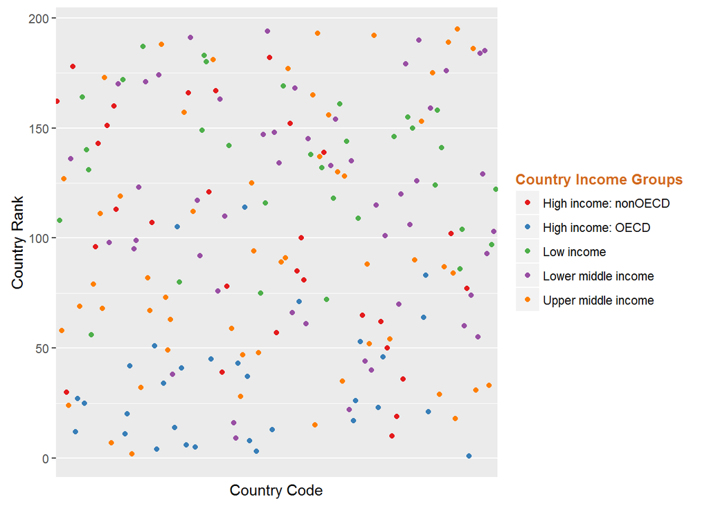

```r
library(ggplot2)
#Creates ggplot
Dataplot <- ggplot(data = cleanset.sorted,aes( x = cleanset.sorted$CountryCode, y = cleanset.sorted$Ranking, group = 1))+geom_point(aes(color=factor(cleanset.sorted$IncomeGroup)))+theme(legend.title = element_text(colour = "chocolate", size = 10, face="bold")) +theme(axis.text.x=element_text(angle= 50, size=10,vjust = 0.5))+scale_color_brewer(palette = "Set1", name="Country Income Groups")+labs(x = "Country Code", y = "Country Rank")+scale_x_discrete(breaks = seq(cleanset.sorted$CountryQuartile))

#Displays plot
Dataplot
```

### 3.4.1 Interpertation of Plot

The Income Group correlates with the GDP ranking for the country. There are some high ranking countries that have Low to Low middle income groupings.

## 3.5 Question 5:

Cut the GDP ranking in 5 separate quantile groups. Make a table versus Income Group.

### 3.5.1 First create Income Group table

```r
#Create income group table with variables Ranking, IncomeGroup, and CountryQuartile variables
library(dplyr)
cleanset.sorted$CountryQuartile <- ntile(cleanset.sorted$Ranking,5)

IncomeGoups <- cleanset.sorted[c(2,5,7)]

#View data in IncomeGroups Table
IncomeGoups
```

```
##     Ranking          IncomeGroup CountryQuartile
## 190     195  Upper middle income               5
## 98      194  Lower middle income               5
## 124     193  Upper middle income               5
## 151     192  Upper middle income               5
## 63      191  Lower middle income               5
## 173     190  Lower middle income               5
## 186     189  Upper middle income               5
## 47      188  Upper middle income               5
## 39      187           Low income               5
## 198     186  Upper middle income               5
## 204     185  Lower middle income               5
## 201     184  Lower middle income               5
## 69      183           Low income               5
## 99      182 High income: nonOECD               5
```

[output cut: 181 more lines]

How many countries are Lower Middle Income but among the 38 nations with the highest GDP?

```r
library(proto)
library(gsubfn)
library(RSQLite)
library(sqldf)
#pulling how many countries have an IncomeGroup equal to Lower Middle Income and is one of the top 38 nations with the highest GDP
sqldf("select count(*) as totalCountries from IncomeGoups where IncomeGroup = 'Lower middle income' and Ranking between 1 and 38")
```

```
##   totalCountries
## 1              4
```